# Estimating the infection and case fatality ratio for COVID-19 using age-adjusted data from the outbreak on the Diamond Princess cruise ship

*Timothy W Russell<sup>1 ††</sup>, Joel Hellewell<sup>1†</sup>, Christopher I Jarvis<sup>1†</sup>, Kevin Van Zandvoort<sup>1†</sup>, Sam Abbott<sup>1</sup>, Ruwan Ratnayake<sup>1,2</sup>, CMMID COVID-19 working group, Stefan Flasche<sup>1</sup>, Rosalind M Eggo<sup>1</sup>, W John Edmunds<sup>1</sup>, Adam J Kucharski<sup>1</sup>*

†† corresponding author: timothy.russell@lshtm.ac.uk

1 Centre for the Mathematical Modelling of Infectious Diseases, Department of Infectious Disease Epidemiology, London School of Hygiene and Tropical Medicine, London, United Kingdom

2 Department of Infectious Disease Epidemiology, London School of Hygiene and Tropical Medicine, London, United Kingdom

3 The members of the Centre for the Mathematical Modelling of Infectious Diseases (CMMID) COVID-19 working group are listed at the end of the article

† authors contributed equally

*corresponding author: timothy.russell@lshtm.ac.uk

## Aim

To estimate the infection and case fatality ratio of COVID-19, using data from passengers of the Diamond Princess cruise ship while correcting for delays between confirmation-and-death, and age-structure of the population.

## Main text

In real-time, estimates of the case fatality ratio (CFR) and infection fatality ratio (IFR) can be biased upwards by under-reporting of cases and downwards by failure to account for the delay from confirmation-to-death. Collecting detailed epidemiological information from a closed population such as the quarantined Diamond Princess can produce a more comprehensive description of asymptomatic and symptomatic cases and their subsequent outcomes. Using data from the Diamond Princess, and adjusting for delay from confirmation-to-outcome and age-structure of the ship’s occupants, we estimated the IFR and CFR for the outbreak in China. As of 3rd March 2020, there have been 92,809 confirmed cases of coronavirus disease 2019 (COVID-19), with 3,164 deaths [1]. On 1st February 2020, a patient tested positive for COVID-19 in Hong Kong; they disembarked from the Diamond Princess cruise ship on the 25th January [2,3]. This patient had onset of symptoms on the 19th January, one day before boarding the ship [2]. Upon returning to Yokohama, Japan, on February 3rd, the ship was held in quarantine, during which testing was performed in order to measure COVID-19 infections among the 3,711 passengers and crew members onboard. Passengers were initially to be held in quarantine for 14 days. However, those that had intense exposure to the confirmed case-patient, such as sharing a cabin, were held in quarantine beyond the initial 14-day window [3]. By 20th February, there were 634 confirmed cases onboard (17%), with 328 of these asymptomatic (asymptomatic cases were either self-assessed or tested positive before symptom onset) [3]. Overall 3,063 PCR tests were performed among passengers and crew members. Testing started among the elderly passengers, descending by age [3]. For details on the testing procedure, see [2] and [3].

## Adjusting for outcome delay in CFR estimates

$$u_{t} = \frac{\sum_{i = 0}^t \sum_{j = 0}^{\infty} c_{i-j} f_j}{\sum_{i = 0}^t c_i},$$

where $c_{t}$ is the daily case incidence at time, $t$, $f_t$ is the proportion of cases with delay between onset or hospitalisation and death. $u_t$ represents the underestimation of the known outcomes [5] and is used to scale the value of the cumulative number of cases in the denominator in the calculation of the cCFR. Finally, we used the measured proportions of asymptomatic to symptomatic cases on the Diamond Princess to scale the corrected CFR (cCFR) to estimate the infection fatality ratio (IFR).

## Corrected IFR and CFR estimates

Using the age-stratified nCFR estimates reported in a large study in China [7], we then calculated the expected number of deaths of people who were onboard the ship in each age group, assuming this nCFR estimate was accurate. This produced a total of 15.15 expected deaths, which gives a nCFR estimate of 5% (15.15/301) for Diamond Princess (Table 2), which falls within the top end of our 95% CI. As our corrected cCFR for Diamond Princess was 2.3% (0.75% - 5.3%), this suggests we need to multiply the nCFR estimates in China [7] by a factor 46% (95% CI: 15–105%) to obtain the correct value. As the raw overall nCFR reported in the China data was 2.3% [7], this suggests the cCFR in China during that period was 1.1% (95% CI: 0.3-2.4%) and the IFR was 0.5% (95% CI: 0.2-1.2%). Based on cases and deaths reported in China up to 4th March 2020, nCFR = 2984/80422*100 = 3.71% (95% CI 3.58% - 3.84%); this naive value is significantly higher than the corrected CFR we estimate here.

[output not shown]

*Table 1: cIFR and cCFR estimates calculated using the reported case and death data on the Diamond Princess cruise ship [2]. Correction was performed using equation (1) and the hospitalisation-to-death distribution in [6].*

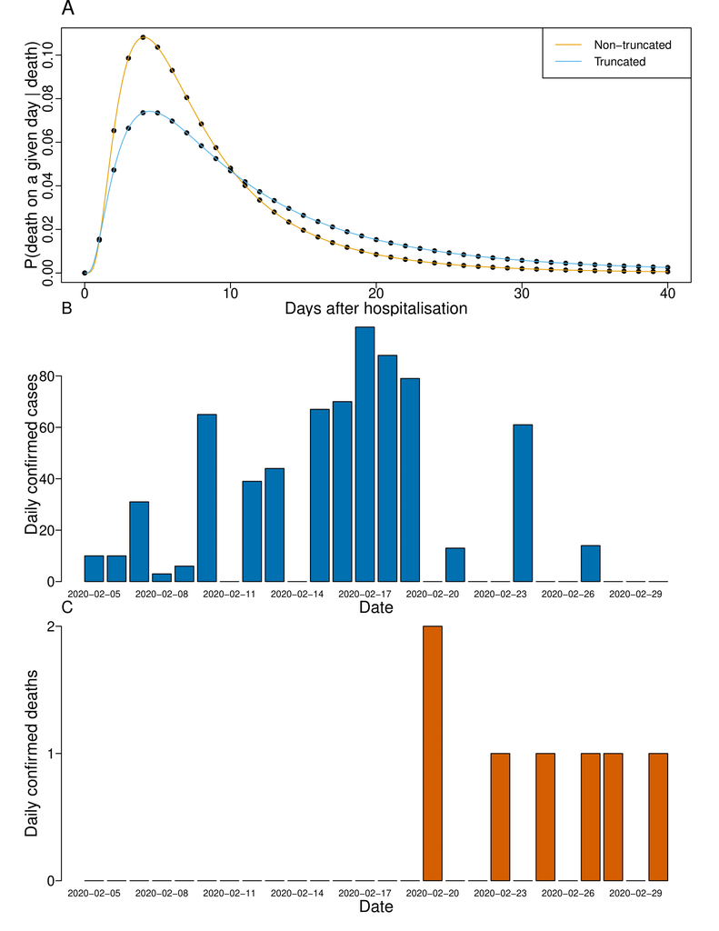

*Figure 1: The time-to-death distributions and case and death data used to calculate the cCFR estimates. Panel A: the delay distributions of hospitalisation-to-death; both are lognormal distributions fitted and reported in Linton et al. using data from the outbreak in Wuhan, China. The non-truncated distribution has a mean of 8.6 days and SD of 6.7 days; the right-truncated distribution has a mean of 13 days and SD of 12.7 days. Panels B and C: the case and death timeseries (respectively) of passengers onboard the ship.*

| Age Range | No. of passengers | Symp. cases | Asymp. cases | nCFR | Expected deaths using nCFR | Observed deaths on cruise ship |
| --- | --- | --- | --- | --- | --- | --- |
| 0 - 9 | 16 | 0 | 1 | 0.0% (0.0% - 0.9%) | 0 (0 - 0) | 0 |
| 10 - 19 | 23 | 2 | 3 | 0.2% (0.0% - 1.0%) | 0 (0 - 0) | 0 |
| 20 - 29 | 347 | 25 | 3 | 0.2% (0.1% - 0.4%) | 0.05 (0.02 - 0.10) | 0 |
| 30 - 39 | 428 | 27 | 7 | 0.2% (0.1% - 0.4%) | 0.06 (0.04 - 0.10) | 0 |
| 40 - 49 | 334 | 19 | 8 | 0.4% (0.3% - 0.6%) | 0.08 (0.06 - 0.12) | 0 |
| 50 - 59 | 398 | 28 | 31 | 1.3% (1.1% - 1.5%) | 0.36 (0.31 - 0.43) | 0 |
| 60 - 69 | 923 | 76 | 101 | 3.6% (3.2% - 4.0%) | 2.74 (2.5 - 3.1) | 0 |
| 70 - 79 | 1015 | 95 | 139 | 8.0% (7.2% - 8.9%) | 7.6 (6.8 - 8.4) | 6 |
| 80 - 89 | 216 | 29 | 25 | 14.8% (13.0% - 16.7%) | 4.28 (3.8 - 4.9) | 1 |
| Totals | 3711 | 301 | 318 |  | 15.15 (13.5 - 17.1) | 7 |

*Table 2: Age stratified data of symptomatic (symp.) and asymptomatic (asymp.) cases on-board the Diamond Princess [2], [3], along with the nCFR estimates given in [7], the expected number of cases in each age group if the nCFR estimates were correct where the total number of expected deaths under these estimates was 15.15 and age stratified observed/expected death ratios.*

The case fatality ratio is challenging to accurately estimate in real time [8], especially for an infection with attributes similar to SARS-CoV-2, which has a delay of almost two weeks between confirmation and death, strong effects of age-dependence and comorbidities on mortality risk, and likely under-reporting of cases in many settings [6]. Using an age-stratified adjustment, we accounted for changes in known outcomes over time. By applying the method to Diamond Princess data, we focus on a setting that is likely to have lower reporting error because large numbers were tested and the test has high sensitivity.

The average age onboard the ship was 58, so our estimates of cCFR cannot directly be applied to a younger population; we therefore scaled our estimates to obtain values for a population equivalent to those in the early China outbreak. There were some limitations to our analysis. Cruise ship passengers may have a different health status to the general population of their home countries, due to health requirements to embark on a multi-week holiday, or differences related to socio-economic status or comborbities. Deaths only occurred in individuals 70 years or older, so we were not able to generate age-specific cCFRs; the fatality risk may also be influenced by differences in healthcare between countries. Because of likely age-specific differences in reporting, we focused on overall cCFR in China, rather than calculating age-specific cCFRs [7].

## References

1 World Health Organization (WHO). Novel Coronavirus (2019-nCoV) Situation Report-43. Geneva: WHO; 3 March 2020. Available from: https://www.who.int/emergencies/diseases/novel-coronavirus-2019/situation-reports.

2 National Institute of Infectious Diseases. Field Briefing: Diamond Princess COVID-19 Cases. https://www.niid.go.jp/niid/en/2019-ncov-e/9407-covid-dp-fe-01.html (accessed 3 Mar2020).

3 National Institute of Infectious Diseases. Field Briefing: Diamond Princess COVID-19 Cases. https://www.niid.go.jp/niid/en/2019-ncov-e/9417-covid-dp-fe-02.html (accessed 3 Mar2020).

4 Kucharski AJ, Edmunds WJ. Case fatality rate for ebola virus disease in west africa. The Lancet 2014;384:1260.

5 Nishiura H, Klinkenberg D, Roberts M et al. Early epidemiological assessment of the virulence of emerging infectious diseases: A case study of an influenza pandemic. PLoS One 2009;4.

6 Linton NM, Kobayashi T, Yang Y et al. Incubation period and other epidemiological characteristics of 2019 novel coronavirus infections with right truncation: A statistical analysis of publicly available case data. Journal of Clinical Medicine 2020;9:538.

7 Wu Z, McGoogan JM. Characteristics of and important lessons from the coronavirus disease 2019 (covid-19) outbreak in china: Summary of a report of 72 314 cases from the chinese center for disease control and prevention. JAMA 2020.

8 Wilson N, Baker M. The emerging influenza pandemic: Estimating the case fatality ratio. Eurosurveillance 2009;14:19255.